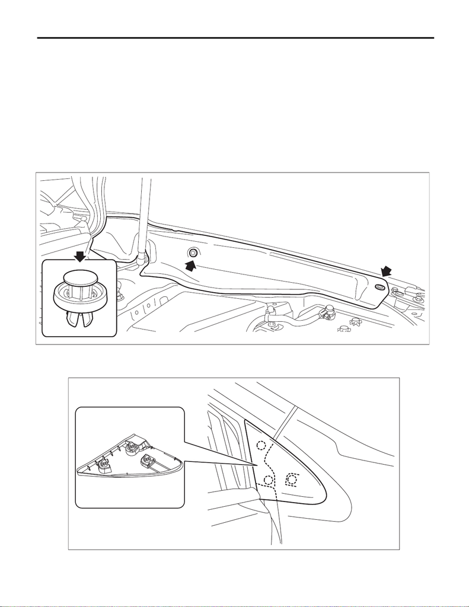

EB-19

Front Fender

EXTERIOR BODY PANELS

3. Front Fender

A: REMOVAL

1. FENDER PANEL

1) Disconnect the ground cable from battery. <Ref. to NT-5, BATTERY, NOTE, Note.>

NOTE:

For models other than STI model, disconnect the ground terminal from battery sensor.

2) Remove the bumper face - front. <Ref. to EI-30, REMOVAL, Front Bumper.>

3) Remove the light assembly - head. <Ref. to LI-23, REMOVAL, Headlight Assembly.>

4) Remove the cover - front fender.

(1) Remove the clip.

(2) Release the claws by pulling them forward, and remove the cover - front fender.

5) Remove the mud guard - front. <Ref. to EI-23, REMOVAL, Mud Guard.>

6) Remove the spoiler assembly - side. <Ref. to EI-50, REMOVAL, Side Garnish.>

7) Remove the cover - front pillar assembly.

8) Remove the garnish assembly - fender. <Ref. to EB-21, FENDER GARNISH, REMOVAL, Front Fender.>

EB-00983

EB-00771

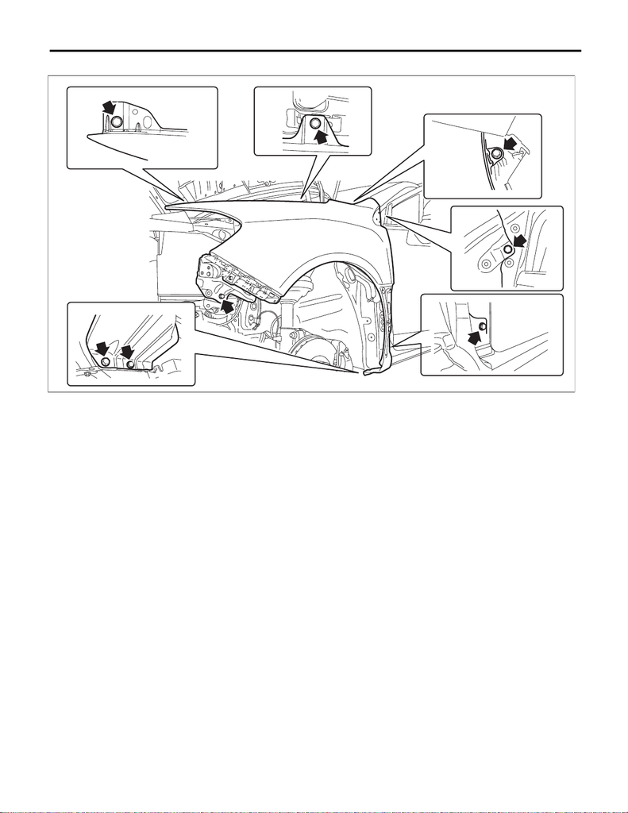

EB-20

Front Fender

EXTERIOR BODY PANELS

9) Remove the fender COMPL - front.

EB-00966

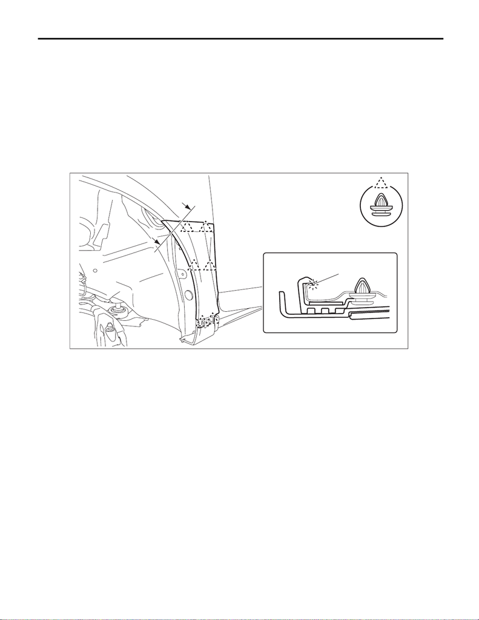

EB-21

Front Fender

EXTERIOR BODY PANELS

2. FENDER GARNISH

1) Remove the mud guard - front. <Ref. to EI-23, REMOVAL, Mud Guard.>

2) Remove the spoiler assembly - side. <Ref. to EI-50, REMOVAL, Side Garnish.>

3) Remove the garnish assembly - fender.

CAUTION:

Forcibly removing the garnish assembly - fender may damage the clips and the garnish assembly -

fender.

NOTE:

• For easy removal of the clips, pinch the claw of clip from the backside of fender COMPL - front with pliers,

etc.

• Because there is a claw (a) at the front end of the garnish assembly - fender, turn from the back side to re-

move.

EB-00967

A

A-A

A

(a)

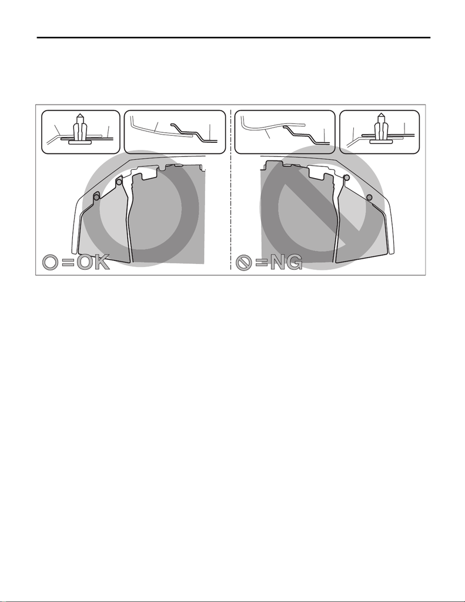

EB-22

Front Fender

EXTERIOR BODY PANELS

B: INSTALLATION

1. FENDER PANEL

CAUTION:

• Install the bumper face - front so that the front end of the under cover (b) comes inside the bumper

face - front (a), and the front end of the mud guard (c) comes outside the bumper face - front (a).

• Before installing the bumper face, match the claws on the bracket - front bumper with the engaging

position of flange section on the bumper face side. If the engaging position is not correct, the flange

section may be broken or the clearance between fender panel and bumper face may not be uniform.

1) Install the fender COMPL - front.

Tightening torque:

7.5 N·m (0.8 kgf-m, 5.5 ft-lb)

NOTE:

When installing the fender COMPL - front, make sure that a uniform clearance is created around it.

• Fender COMPL - front to Hood COMPL - front: <Ref. to EB-17, ADJUSTMENT, Front Hood.>

• Fender COMPL - front to Panel assembly - front door: <Ref. to EB-30, ADJUSTMENT, Front Door.>

2) Install the cover - front pillar assembly.

3) Install the garnish assembly - fender. <Ref. to EB-23, FENDER GARNISH, INSTALLATION, Front Fend-

er.>

4) Install the spoiler assembly - side. <Ref. to EI-50, INSTALLATION, Side Garnish.>

5) Install the mud guard - front.

6) Install the light assembly - head.

Tightening torque:

7.5 N·m (0.8 kgf-m, 5.5 ft-lb)

7) Install the bumper face - front. <Ref. to EI-34, INSTALLATION, Front Bumper.>

8) Connect the battery ground terminal. <Ref. to NT-5, BATTERY, NOTE, Note.>

NOTE:

For models other than STI model, connect the ground terminal to battery sensor.

9) Adjust the headlight beam and fog light beam.

• Adjust the headlight beam. <Ref. to LI-26, HEADLIGHT BEAM ADJUSTMENT, ADJUSTMENT, Headlight

Assembly.>

• Adjust the fog light beam. (Model with fog light) <Ref. to LI-43, FOG LIGHT AIMING, ADJUSTMENT, Front

Fog Light Assembly.>

COM00138

(a)

(c)

(b)

(a)

(a)

(c)

(b)

(a)

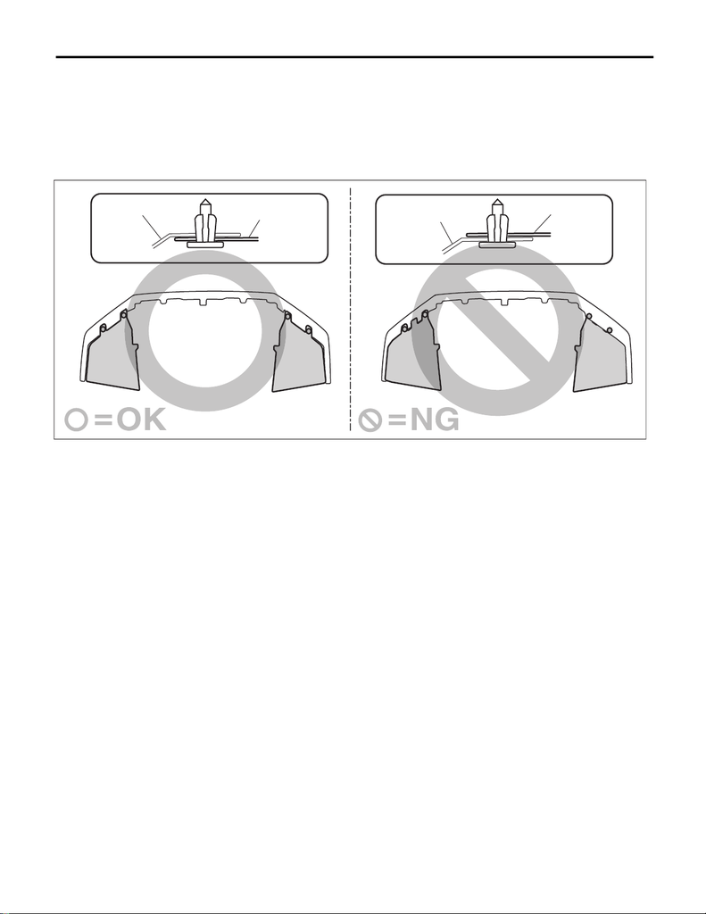

EB-23

Front Fender

EXTERIOR BODY PANELS

2. FENDER GARNISH

1) Install the garnish assembly - fender.

2) Install the spoiler assembly - side. <Ref. to EI-50, INSTALLATION, Side Garnish.>

3) Install the mud guard - front.

CAUTION:

Install the mud guard - front so that the front end of the mud guard (b) comes outside the bumper face

- front (a).

COM00136

(a)

(b)

(a)

(b)